# P4-Perceptual_Phenomenon - Stroop_Effect

## Test a Perceptual Phenomenon - Stroop Effect

### Background Information

In a Stroop task, participants are presented with a list of words, with each word displayed in a color of ink. The participant’s task is to say out loud the color of the ink in which the word is printed. The task has two conditions: a congruent words condition, and an incongruent words condition.

1. In the congruent words condition, the words being displayed are color words whose names match the colors in which they are printed: for example RED, BLUE.
2. In the incongruent words condition, the words displayed are color words whose names do not match the colors in which they are printed: for example PURPLE, ORANGE.

In each case, we measure the time it takes to name the ink colors in equally-sized lists. Each participant will go through and record a time from each condition.

```python
import pandas as pd
import numpy as np
import matplotlib.pyplot as plt
%matplotlib inline

df=pd.read_csv('Datasets/stroopdata.csv')
df
```

|  | Congruent | Incongruent |
| --- | --- | --- |
| 0 | 12.079 | 19.278 |
| 1 | 16.791 | 18.741 |
| 2 | 9.564 | 21.214 |
| 3 | 8.630 | 15.687 |
| 4 | 14.669 | 22.803 |
| 5 | 12.238 | 20.878 |
| 6 | 14.692 | 24.572 |
| 7 | 8.987 | 17.394 |
| 8 | 9.401 | 20.762 |
| 9 | 14.480 | 26.282 |
| 10 | 22.328 | 24.524 |
| 11 | 15.298 | 18.644 |
| 12 | 15.073 | 17.510 |
| 13 | 16.929 | 20.330 |
| 14 | 18.200 | 35.255 |
| 15 | 12.130 | 22.158 |
| 16 | 18.495 | 25.139 |
| 17 | 10.639 | 20.429 |
| 18 | 11.344 | 17.425 |
| 19 | 12.369 | 34.288 |
| 20 | 12.944 | 23.894 |
| 21 | 14.233 | 17.960 |
| 22 | 19.710 | 22.058 |
| 23 | 16.004 | 21.157 |

**Q1: What is the independent variable? What is the dependent variable?**

Independent Variables is the congruency of color and text.

Dependent Variables is the duration to recognise the colors or the texts.

**Q2: What is an appropriate set of hypotheses for this task? What kind of statistical test do you expect to perform? Justify your choices.**

Let us consider μi as reaction time under incongruent conditions, and μc as reaction time under congruent conditions.

The Null Hypothesis Ho is described as, when there is no observable difference in the average response time for identifying congruent words(μc) when compared to viewing the incongruent words(μi).

`μi - μc = 0`

The Alternative Hypothesis Ha is described as, when there is a observable difference in the average response time for identifying congruent words(μc) when compared to viewing the incongruent words(μi).

`μi - μc ≠ 0`

Here `μ` conveys the population mean.

We can consider **bootstrapping**, where we can use the sample function to extrapolate the dataset as a whole, and simulate the distribution with the size of the boostrapped differences.

**Q3: Report some descriptive statistics regarding this dataset. Include at least one measure of central tendency and at least one measure of variability.**

Lets calculate Measures of central tendency

1. Mean
2. Median

```python
congruent_mean = df['Congruent'].mean()
congruent_mean
```

```
14.051125000000004
```

```python
incongruent_mean = df['Incongruent'].mean()
incongruent_mean
```

```
22.01591666666667
```

```python
Congruent_median = df['Congruent'].median()
Congruent_median
```

```
14.3565
```

```python
incongruent_median = df['Incongruent'].median()
incongruent_median
```

```
21.0175
```

Lets calculate Measures of variability

1. Standard Deviation
2. Variance

```python
congruent_std = df['Congruent'].std()
congruent_std
```

```
3.559357957645195
```

```python
incongruent_std = df['Incongruent'].std()
incongruent_std
```

```
4.797057122469138
```

```python
congruent_var = df['Congruent'].var()
congruent_var
```

```
12.669029070652174
```

```python
incongruent_var = df['Incongruent'].var()
incongruent_var
```

```
23.011757036231884
```

**Q4: Provide one or two visualizations that show the distribution of the sample data. Write one or two sentences noting what you observe about the plot or plots.**

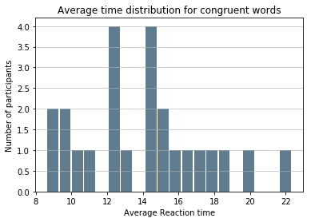

```python
plt.hist(df['Congruent'], bins=20, rwidth=0.9,color='#607c8e')
plt.title('Average time distribution for congruent words')
plt.xlabel('Average Reaction time')
plt.ylabel('Number of participants')
plt.grid(axis='y', alpha=0.75)
```

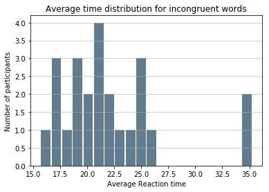

```python
plt.hist(df['Incongruent'], bins=20, rwidth=0.9,color='#607c8e')
plt.title('Average time distribution for incongruent words')
plt.xlabel('Average Reaction time')
plt.ylabel('Number of participants')
plt.grid(axis='y', alpha=0.75)
```

Further, we can use kernel density estimation (KDE) to estimate the probability density function (PDF) of the random variable that “underlies” our sample. KDE is a means of data smoothing.

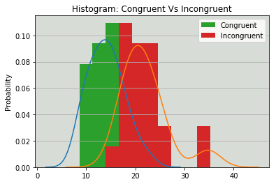

```python
fig, ax = plt.subplots()
df.plot.kde(ax=ax, legend=False, title='Histogram: Congruent Vs Incongruent')
df.plot.hist(density=True, ax=ax)
ax.set_ylabel('Probability')
ax.grid(axis='y')
ax.set_facecolor('#d8dcd6')
```

Q5: Now, perform the statistical test and report your results.  
What is your confidence level or Type I error associated with your test?  
What is your conclusion regarding the hypotheses you set up?  
Did the results match up with your expectations?  
Hint: Think about what is being measured on each individual, and what statistic best captures how an individual reacts in each environment.

Lets extrapolate the difference of means for congruent and incongruent word conditions to get normally disributed values for further analysis.

```
Text(0.5,1,'Distribution of Reaction Time')
```

[figure not shown]

```python
difference = []

for i in range(1000):
    sample = df.sample(df.shape[0], replace = True)
    incon_sample = sample['Incongruent'].mean()
    con_sample = sample['Congruent'].mean()
    diff = incon_sample - con_sample
    difference.append(diff)

diffs_arr = np.asarray(diffs)

plt.hist(diffs_arr, bins=10, rwidth=0.9,color='#607c8e')
plt.xlabel('Reaction Time (Seconds)')
plt.ylabel('Number of Participants')
plt.title('Distribution of Reaction Time')
```

Under the null hypothesis, we simulate the distribution with the size of the boostrapped differences and calculate standard deviation.

```python
null_vals = np.random.normal(0, diffs_arr.std(), diffs_arr.size)
```

Further, we plot the null distibution and the mean of the observed differences.

[figure not shown]

```python
plt.hist(null_vals, bins=10, rwidth=0.9,color='#607c8e')
plt.axvline(x = incongruent_mean-congruent_mean, color = 'blue', label = 'Observed Avg Difference')
plt.xlabel('Reaction Time (Seconds)')
plt.ylabel('Number of Observations')
plt.title('Average Reaction Time Null Hypothesis')
plt.legend()
plt.show()
```

**Observation**

The observed differences are far from the differences simulated under the null hypothesis which indicates a big difference between the observed values and the values of the null hypothesis. Calculating p-value below:

```python
(null_vals > diffs_arr).mean()
```

```
0.0
```

## Conclusion

Based on our p-value calculation and the visualization, we can reject the null hypothesis.

The p-value is zero which is less than significant level, indicating that there are not any values in the statistics which could match with the values generated under the null hypothesis. According to our observations, we can conclude that reaction time of participants is higher under incongruent conditions.

This is an awesome dataset, which correctly validates the stroop effect.

## Resources

1. https://www.udacity.com/course/viewer#!/c-ud134-nd/l-4446458586/
2. https://realpython.com/python-histograms/
3. http://www.statisticssolutions.com/dependent-sample-t-test-2-tailed/
4. http://influentialpoints.com/Training/paired_t-test-principles-properties-assumptions.htm
5. http://www2.psychology.uiowa.edu/faculty/mordkoff/GradStats/part%201/I.07%20normal.pdf
6. https://www.burns-stat.com/documents/tutorials/the-statistical-bootstrap-and-other-resampling-methods-2/